[Статьи]

# Сравнение традиционного и конденсационного газовых котлов (расчётная часть статьи)

Текстовую часть статьи см. [здесь](https://dzen.ru/a/ZhJ0VC2zRlZ6aioa).

```python
Q_CH4 = 50e6  # низшая теплота сгорания метана, Дж/кг
Q_кт = 25e3  # тепловая мощность традиционного котла, Вт
КПД_кт = 0.929  #  КПД традиционного котла
G_дгк = 0.017  # массовый расход дымовых газов из каталога производителя
t_дг = 135 # температура дымовых газов из котла, С
alfa = 1.83  # коэффициент избытка воздуха
```

```python
Q_т = Q_кт / КПД_кт  # тепловая мощность выделяемая при сгорании топлива, Вт
Q_т  #  Вт
```

```
26910.656620021527
```

```python
G_CH4 = Q_т / Q_CH4  # расход метана, кг/с
G_CH4  # кг/с
```

```
0.0005382131324004305
```

```python
g_возд = 17.39  # количество воздуха, необходимое для полного для сжигания 1 кг метана, кг/кг
G_дг = G_CH4 * (1 + alfa * g_возд)  # расчётное значение массового расхода дымовых газов, кг/с
G_дг  # кг/с
```

```
0.017666146393972012
```

```python
(G_дг - G_дгк) / G_дгк * 100  # невязка расходов дымовых газов, %
```

```
3.9185081998353564
```

Далее в качестве величины расхода дымовых газов будем использовать G_дг

```python
c_дг = 1006  # теплоёмкость дымовых газов, Дж/кг/К
```

```python
t_пр = 80; t_обр = 60  # температура прямой и обратной воды, С
#dt_вых = 15  # температурный напор на холодном конце экономайзера, С
```

```python
# Обратным счётом найдём температуру продуктов сгорания в камере сгорания котла
t_кс = Q_кт / c_дг / G_дг + t_дг
t_кс
```

```
1541.6958394891547
```

```python
# Тепловая мощность от охлаждения дымовых газов
def fQ(t_обр, dt_вых = 15):
    return (t_кс - (t_обр + dt_вых)) * c_дг * G_дг
Q_dt15 = fQ(t_обр)
Q_dt15
```

```
26066.328596340154
```

Дополнительная тепловая мощность может быть принята посредством увеличения расхода теплоносителя при неизменных значениях температуры прямой и обратной сетевой воды либо увеличением степени нагрева воды при неизменном расходе.

```python
# Увеличения расхода теплоносителя при неизменной степени нагрева в котле
(Q_dt15 - Q_кт) / Q_кт
```

```
0.04265314385360616
```

```python
# Увеличение нагрева сетевой воды при неизменном расходе, С
(t_пр - t_обр) * (Q_dt15 - Q_кт) / Q_кт
```

```
0.8530628770721232
```

### Среднелогарифмический температурный напор

Величина тепловой мощности, передаваемой от горячего потока (дымовые газы) холодному потоку (сетевая вода) находится по формуле: $$Q = k \overline{\Delta t} F\qquad \qquad $$ где $Q$ - тепловая мощность, подводимая к сетевой воде от дымовых газов, Вт; $k$ - коэффициент теплопередачи, $Вт/(м^2\cdot K)$; $F$ - площадь поверхности теплообмена, $м^2$; $\overline{\Delta t}$ - cреднелогарифмический температурный напор $$\overline{\Delta t} = \frac{\Delta t_{нач} - \Delta t_{кон}}{\ln(\Delta t_{нач}/\Delta t_{кон})}$$ Для теплообменника прямоточного типа $$\Delta t_{нач} = t_г^{вх} - t_{х}^{вх};\, \Delta t_{кон} = t_г^{вых} - t_{х}^{вых}$$ Для теплообменника противоточного типа $$\Delta t_{нач} = t_г^{вх} - t_{х}^{вых};\, \Delta t_{кон} = t_г^{вых} - t_{х}^{вх}$$

где $t_х^{вх}$ - температура холодного потока на входе в теплообменник, C; $t_х^{вых}$ - температура холодного потока на выходе из теплообменника, C; $t_г^{вх}$ - температура горячего потока на входе в теплообменник, C; $t_г^{вых}$ - температура горячего потока на выходе из теплообменника, C.

Среднелогорифмический температурный напор пропорционален отношению тепловой мощности к площади поверхности теплообмена

$$\overline{\Delta t} \sim Q / F$$

Определим зависимость среднелогорифмического температурного напора от температуры дымовых газов на выходе котла исходя из предположения, что в газовом котле используется противоточный теплообменник.

```python
from math import log
# Функция для расчёта среднелогорифмического температурного напора
def fdt_ср(dt_кон = t_дг - t_обр):
    if dt_кон <= 0: raise ValueError('Температура дымовых газов должна быть выше температуры обратной воды')
    dt_нач = t_кс - t_пр
    return (dt_нач - dt_кон) / log(dt_нач / dt_кон)
```

```python
import numpy as np  # библиотека для работы с массивами
ts_дг = np.linspace(t_обр + 15, 300)
ts_ср = np.zeros_like(ts_дг)
for i, t in enumerate(ts_дг):
    ts_ср[i] = fdt_ср(ts_дг[i] - t_обр)
```

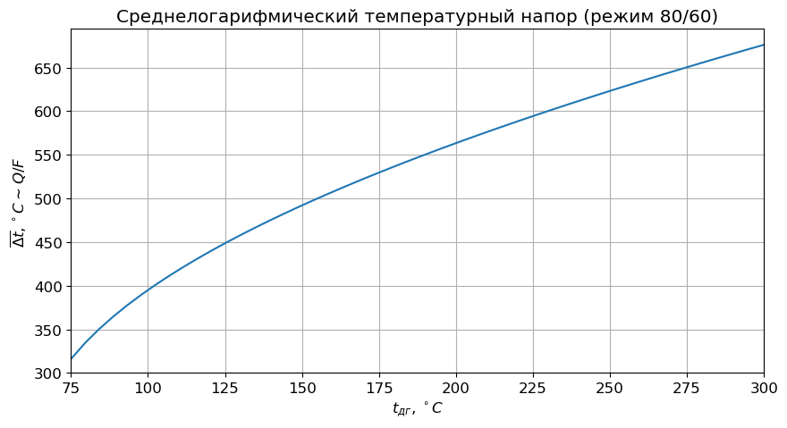

```python
import matplotlib.pyplot as plt  # библиотека для построения графиков
plt.rcParams['font.size'] = 12.0
fig, ax = plt.subplots(figsize = (10,5))
ax.set_title("Среднелогарифмический температурный напор (режим 80/60)")
ax.set_xlabel('$t_{дг}$, $^\circ C$'); ax.set_ylabel('$\overline{\Delta t}, ^\circ C \sim Q / F$')
# ax.plot([p1_x, p2_x], [p1_y, p2_y], label = "$d(Q/F)=const$")
#ax.plot(ts_дг, ts_ср, label = "Реальный котёл")
ax.plot(ts_дг, ts_ср)
ax.grid(); ax.set_xlim(ts_дг[0], ts_дг[-1]); ax.set_ylim(300,); # ax.legend();
```

## Конденсационный котёл

### Определим количество водяного пара, содержащегося в дымовых газах

```python
v_O2 = 0.21; v_N2 = 1 - v_O2  # объёмные доли кислорода и азота в воздухе
```

```python
# Молярные массы компонентов воздуха и метана, г/моль
H = 1; C = 12; N = 14; O = 16
mus = {'N2': N*2, 'O2': O*2, 'CO2': C+O*2, 'H2O': H*2+O, 'CH4' : C+H*4}
mus
```

```
{'N2': 28, 'O2': 32, 'CO2': 44, 'H2O': 18, 'CH4': 16}
```

Реакция горение менана: CH4 + 2O2 = CO2 + 2H2O

```python
# Состав дымовых газов при сжигатии 1 моль CH4, коэффмцмент избытка воздуха alfa
Vs_дг = {'CO2': 1, 'H2O': 2, 'N2': 2 * v_N2 / v_O2 * alfa, 'O2': 2 * (alfa - 1)}
Vs_дг
```

```
{'CO2': 1, 'H2O': 2, 'N2': 13.76857142857143, 'O2': 1.6600000000000001}
```

```python
# количество молей дымовых газов при сжигании моля CH4 с заданным alfa
сум = sum(Vs_дг.values())
сум
```

```
18.42857142857143
```

```python
vs_дг = {}  # мольные (объёмные) доли
for elem in Vs_дг.keys():
    vs_дг[elem] = Vs_дг[elem] / сум
vs_дг
```

```
{'CO2': 0.05426356589147286,
 'H2O': 0.10852713178294572,
 'N2': 0.7471317829457365,
 'O2': 0.09007751937984496}
```

```python
# Молярная масса дымовых газов
mu_дг = 0
for elem in vs_дг.keys():
    mu_дг += mus[elem] * vs_дг[elem]
mu_дг  # г/моль
```

```
28.14325581395349
```

```python
# Объёмный расход дымовых газов
Q_дг = G_дг * 1000 / mu_дг
Q_дг # моль/с
```

```
0.6277221978422659
```

```python
# Массовый расход водяного пара, г/с
Q_дг * vs_дг['H2O'] * mus['H2O']
```

```
1.2262480143895425
```

```python
dh_конд = 2500e3  # скрытая теплота парообразования, Дж/кг
# Тепловая мощность, выделяемая при конденсации всего водяного пара, содержащенгося в дымовых газах
dQ_к = Q_дг * vs_дг['H2O'] * mus['H2O'] / 1000 * dh_конд
dQ_к  # Вт
```

```
3065.620035973856
```

```python
p_дг = 1e5  # давление дымовых газов (атмосферное давление), Па
```

```python
# Парциальное давление пара
p_H2O = vs_дг['H2O'] * p_дг
p_H2O
```

```
10852.713178294573
```

```python
# Определим температуру точки росы дымовых газов
from wetairprops import calc_t_s, calc_p_s  # см. [2]
t_тр = calc_t_s(p_H2O)
t_тр  # градусы Цельсия
```

```
47.41965122525831
```

```python
v_дг_без_H20 = 1. - vs_дг['H2O']
```

```python
# Уменьшение давления дымовых газов при конденсации пара учитывать не будем
ts_дг1 = np.linspace(5, t_тр-0.01)  # у ГВС температурный режим 60/5
dQs_охл = []  # Дополнительная тепловая мощтсть от более глубокого охлаждения дымовых газов
dQs_конд = []  # Дополнительная тепловая мощность от конденсации водяного пара
for t in ts_дг1:
    v_H2O = calc_p_s(t) / p_дг # при уменьшенном расходе
    v_H2O = v_дг_без_H20 / (1 - v_H2O) * v_H2O  # относительно изначального расхода
    dv_H2O = vs_дг['H2O'] - v_H2O
    dm_H2O = dv_H2O * Q_дг * mus['H2O'] / 1000
    dQs_охл.append((t_дг - t) * c_дг * G_дг)
    dQs_конд.append(dm_H2O * dh_конд)
dQs_охл = np.array(dQs_охл); dQs_конд = np.array(dQs_конд)
```

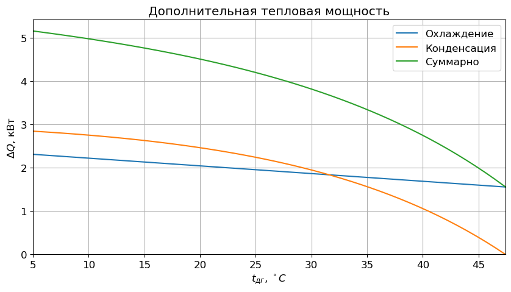

```python
fig, ax = plt.subplots(figsize = (10,5))
ax.set_title("Дополнительная тепловая мощность")
ax.set_xlabel('$t_{дг}$, $^\circ C$'); ax.set_ylabel('$\Delta Q$, кВт')
ax.plot(ts_дг1, dQs_охл / 1000, label = "Охлаждение")
ax.plot(ts_дг1, dQs_конд / 1000, label = "Конденсация")
ax.plot(ts_дг1, (dQs_охл + dQs_конд) / 1000, label = "Суммарно")
ax.grid(); ax.set_xlim(ts_дг1[0], ts_дг1[-1]); ax.set_ylim(0,); ax.legend();
```

```python
# Функция для расчёта среднелогорифмического температурного напора
t_пр = 50; t_обр = 30
def fdt_ср1(dt_кон):
    if dt_кон <= 0: raise ValueError('Температура дымовых газов должна быть выше температуры обратной воды')
    dt_нач = t_кс - t_пр
    return (dt_нач - dt_кон) / log(dt_нач / dt_кон)
ts_дг = np.linspace(t_обр + 5, 300)
ts_ср = np.zeros_like(ts_дг)
for i, t in enumerate(ts_дг):
    ts_ср[i] = fdt_ср1(ts_дг[i] - t_обр)
```

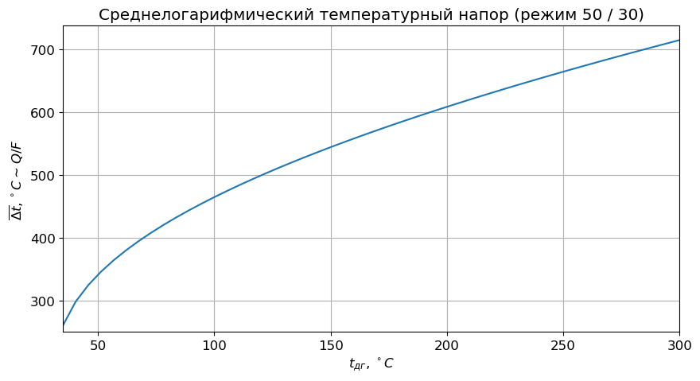

```python
fig, ax = plt.subplots(figsize = (10,5))
ax.set_title("Среднелогарифмический температурный напор (режим 50 / 30)")
ax.set_xlabel('$t_{дг}$, $^\circ C$'); ax.set_ylabel('$\overline{\Delta t}, ^\circ C \sim Q / F$')
# ax.plot([p1_x, p2_x], [p1_y, p2_y], label = "$d(Q/F)=const$")
#ax.plot(ts_дг, ts_ср, label = "Реальный котёл")
ax.plot(ts_дг, ts_ср)
ax.grid(); ax.set_xlim(ts_дг[0], ts_дг[-1]); ax.set_ylim(250,); # ax.legend();
```

### Эксергетический КПД

```python
# Количество теплоты выделемой при горении метана в камере сгорания котла, Вт
# может быть любым значением кроме нуля, т.к. сокращается в формуле для КПД
Q_гор = 25000
t_гор_CH4 = 1900; T_гор_CH4 = t_гор_CH4 + 273.15  # температура горения метана
t_ос = -2.2; T_ос = t_ос + 273.15  # cредняя температура наружного воздуха за отопительный период в Москве
t_1_т = (80 + 60) / 2; T_1_т = t_1_т + 273.15  # средняя температура сетевой воды на режиме 80/60
t_1_к = (50 + 30) / 2; T_1_к = t_1_к + 273.15  # средняя температура сетевой воды на режиме 50/30
КПД_т = 0.9; КПД_к = 1.  # КПД традиционного и конденсационного котлов
```

```python
Ex_CH4 = Q_гор * (T_гор_CH4 - T_ос) / T_гор_CH4  # эксергия теплоты сгорания метана
Ex_т = Q_гор * КПД_т * (T_1_т - T_ос) / T_1_т  # эксергия теплоты прямой воды традиционного котла
Ex_к = Q_гор * КПД_к * (T_1_к - T_ос) / T_1_к  # эксергия теплоты прямой воды конденсационного котла
Ex_CH4, Ex_т, Ex_к  # эксергия, Вт
```

```
(21882.980926305132, 4734.081305551507, 3368.9924956091327)
```

```python
Ex_т / Ex_CH4, Ex_к / Ex_CH4  # эксергетический КПД
```

```
(0.2163362167839188, 0.15395491624083665)
```

```python
T_ос
```

```
270.95
```

```python
# Эксергетический КПД электрообогревателя
t_1_эл = 60; T_1_эл = t_1_эл + 273.15  # температура электрообогревателя
Q_эл = Q_гор  # тепловая мощность электрообогревателя
Ex_эл = Q_эл * (T_1_эл - T_ос) / T_1_эл
Ex_эл / Q_эл # эксергетический КПД
```

```
0.18670268647756263
```

### Ссылки

1. [Состав выхлопных газов при сжигании газового топлива](https://medsv.github.io/dzen/0035/Состав_выхлопных_газов.html)
2. [Модуль для расчёта свойств влажного воздуха](https://medsv.github.io/dzen/0048/wetairprops.html)
3. [Температура точки росы продуктов сгорания газового топлива](https://medsv.github.io/dzen/0040/Точка_росы_прод_сгор.html)
4. В. М. Бродянский. Вечный двигатель - прежде и теперь. Москва. Энергоатамиздат. 1989.

[Инженерные расчёты на Python](https://zen.yandex.ru/id/5f33dcd5554adc5b33aaee83), С.В. Медведев, 2020-2024  
[Использование Python и Jupyter Notebook для инженерных расчётов](https://medsv.github.io/dzen/), С.В. Медведев, 2020-2024